# Sheet 5 Exercise 1: Nonlinear Network with Divisive Inhibition (Credits: 4)

Note: All computations are supposed to be carried out by hand! You need to submit your computations to complete the exercise. You can either write your computations into the notebook using LaTeX syntax, or submit them on paper (scan).

Consider a network consisting of two neurons, given by $$\begin{align}\tau\dot{u}_1(t) = -u_1(t) + \frac{s_1}{1+u_2(t)}, \\ \tau \dot{u}_2(t) = -u_2(t) + \frac{s_2}{1 + u_1(t)}. \end{align}$$ The inputs $s_1$, $s_2$ are assumed to be non-negative.

#### 1.1

Show that when $u_1(0)\geq 0$ and $u_2(0) \geq 0$, then $u_1(t) \geq 0$ and $u_2(t) \geq 0$ for all $t\geq 0$.

*Hint:* Think about what happens on the boundaries of the quadrant, i.e. where $u_1=0$ or $u_2=0$.

From now on, we only consider states where $u_1 \geq 0$ and $u_2 \geq 0$.

#### 1.2

Compute the relevant fixed points of the system for $s_1=s_2 \geq 0$. Compute them explicitly for $s=0$ and $s=\frac{3}{4}$.

#### 1.3

Compute the linearized system for the obtained relevant fixed points and analyze their stability.

#### 1.4

Plot the system's dynamics for the two input signals using a quiver plot. Do the plots confirm your results from 1.2 and 1.3?

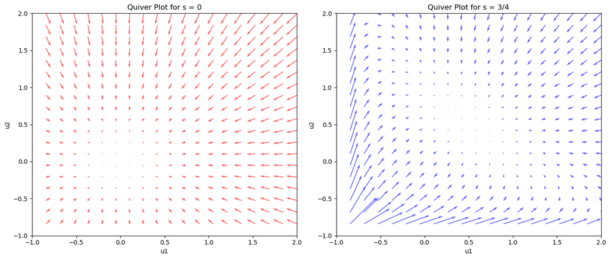

```python
### CODE FOR YOUR PLOTS HERE ###
import numpy as np
import matplotlib.pyplot as plt

# Define the system of equations
def system(u1, u2, s):
    tau = 1  # Assuming tau = 1 for simplicity
    du1 = -u1 + s / (1 + u2)
    du2 = -u2 + s / (1 + u1)
    return du1, du2

# Create a grid of points (u1, u2)
u1 = np.linspace(-1, 2, 20)
u2 = np.linspace(-1, 2, 20)
U1, U2 = np.meshgrid(u1, u2)

# Set up the figure and axes
fig, axes = plt.subplots(1, 2, figsize=(14, 6))

# Plot for s = 0
s = 0
V1, V2 = system(U1, U2, s)
axes[0].quiver(U1, U2, V1, V2, color='r', alpha=0.6)
axes[0].set_title("Quiver Plot for s = 0")
axes[0].set_xlabel("u1")
axes[0].set_ylabel("u2")
axes[0].set_xlim(-1, 2)
axes[0].set_ylim(-1, 2)
axes[0].grid(False)

# Plot for s = 3/4
s = 3/4
V1, V2 = system(U1, U2, s)
axes[1].quiver(U1, U2, V1, V2, color='b', alpha=0.6)
axes[1].set_title("Quiver Plot for s = 3/4")
axes[1].set_xlabel("u1")
axes[1].set_ylabel("u2")
axes[1].set_xlim(-1, 2)
axes[1].set_ylim(-1, 2)
axes[1].grid(False)
plt.tight_layout()
plt.show()

### CODE FOR YOUR PLOTS HERE ###
```

#### 1.5

Derive a Lyapunov function for this system. Where is this function's time derivative negative, and what does that mean for the stability of the system?

*Hint:* In the lecture, we discussed a theorem that can be used to derive a Lyapunov function for this system.